# Reach metabolism and drainage area: three HUC8 examples

## Purpose

This is a deliberately **reach-level** view of the drainage-area question. Each point and line is one MERIT flowline, its x value is MERIT upstream drainage area, and its y/color value is that flowline’s annual mean metabolism rate. Nothing is accumulated upstream for these figures. That distinction matters: using cumulative metabolism against cumulative area can create a partly mechanical relationship because both quantities contain the same upstream network.

The three HUC8s were selected once from `04c_huc08_summary.csv`. Each has at least 20 flowlines with positive GPP and ER in all 12 months, at least one headwater in the retained network, and represents a different part of CONUS. No watershed discovery or web request occurs in this document.

## Read the fixed HUC8 selection and local data

```r
dir_processed <- "../data/processed"

path_riv <- file.path(
  dir_processed,
  "merit_data/03_riv_pfaf_7_MERIT_Hydro_v07_Basins_v01_CONUS_filtered.shp"
)
path_metabolism <- file.path(
  dir_processed,
  "03_filtered_maavara_monthly_metabolism.rds"
)
path_huc08_key <- file.path(dir_processed, "04c_comid_huc08_key.rds")
path_huc08_summary <- file.path(dir_processed, "04c_huc08_summary.csv")
path_huc08_boundaries <- file.path(dir_processed, "04c_huc08_boundaries.gpkg")

selected_huc08 <- tribble(
  ~huc8,       ~region,
  "17070301", "Upper Deschutes, Oregon",
  "11020009", "Upper Arkansas, Colorado–Kansas",
  "03080101", "Upper St. Johns, Florida"
)

huc08_key <- readRDS(path_huc08_key)
huc08_summary <- read_csv(path_huc08_summary, show_col_types = FALSE)

selection_summary <- huc08_summary %>%
  inner_join(selected_huc08, by = "huc8") %>%
  select(
    region,
    huc8,
    huc8_name,
    l1_ecoregion,
    n_flowlines,
    n_complete_flowlines,
    n_headwaters,
    pct_area_covered,
    log10_uparea_range
  )

stopifnot(
  nrow(selection_summary) == 3,
  all(selection_summary$n_complete_flowlines >= 20),
  all(selection_summary$n_headwaters > 0)
)

selection_summary
```

```
## # A tibble: 3 × 9
##   region           huc8  huc8_name l1_ecoregion n_flowlines n_complete_flowlines
##   <chr>            <chr> <chr>     <chr>              <dbl>                <dbl>
## 1 Upper St. Johns… 0308… Upper St… Eastern Tem…         253                  251
## 2 Upper Arkansas,… 1102… Upper Ar… Great Plains         242                  238
## 3 Upper Deschutes… 1707… Upper De… Northwester…         134                  104
## # ℹ 3 more variables: n_headwaters <dbl>, pct_area_covered <dbl>,
## #   log10_uparea_range <dbl>
```

```r
annual_metabolism <- readRDS(path_metabolism) %>%
  clean_names() %>%
  mutate(comid = as.character(comid)) %>%
  group_by(comid) %>%
  summarise(
    GPP = mean(gpp_g_o2_m2_d, na.rm = TRUE),
    ER = mean(er_g_o2_m2_d, na.rm = TRUE),
    .groups = "drop"
  )

selected_key <- huc08_key %>%
  inner_join(selected_huc08, by = "huc8") %>%
  filter(
    n_good_both_months == 12,
    is.finite(uparea_km2),
    uparea_km2 > 0
  )

selected_reaches_wide <- read_sf(path_riv) %>%
  clean_names() %>%
  transmute(comid = as.character(comid), geometry) %>%
  inner_join(
    selected_key %>%
      select(comid, huc8, region, uparea_km2, is_headwater_retained),
    by = "comid"
  ) %>%
  left_join(annual_metabolism, by = "comid")

selected_reaches <- selected_reaches_wide %>%
  pivot_longer(
    c(GPP, ER),
    names_to = "process",
    values_to = "metabolism_g_o2_m2_d"
  ) %>%
  mutate(process = factor(process, levels = c("GPP", "ER")))

selected_boundaries <- read_sf(path_huc08_boundaries) %>%
  inner_join(selected_huc08, by = "huc8")

# ggplot2 does not allow free spatial scales inside facet_wrap/facet_grid.
# Build one map per basin and arrange those maps as aligned panels instead.
draw_map_panel <- function(region_i, process_i, show_legend = FALSE) {
  process_range <- selected_reaches %>%
    st_drop_geometry() %>%
    filter(process == process_i) %>%
    summarise(
      lower = min(metabolism_g_o2_m2_d),
      upper = max(metabolism_g_o2_m2_d)
    )

  ggplot() +
    geom_sf(
      data = selected_boundaries %>% filter(region == region_i),
      fill = "grey97",
      color = "grey35",
      linewidth = 0.45
    ) +
    geom_sf(
      data = selected_reaches %>%
        filter(region == region_i, process == process_i),
      aes(color = metabolism_g_o2_m2_d),
      linewidth = 0.75
    ) +
    scale_color_viridis_c(
      trans = "log10",
      option = "C",
      limits = c(process_range$lower, process_range$upper),
      name = paste("Annual mean", process_i)
    ) +
    labs(title = region_i) +
    theme(
      panel.grid = element_blank(),
      plot.title = element_text(size = 10, face = "bold", hjust = 0.5),
      legend.position = if (show_legend) "bottom" else "none"
    )
}

make_map_row <- function(process_i) {
  regions <- selected_huc08$region

  panels <- lapply(
    regions,
    function(region_i) draw_map_panel(region_i, process_i)
  )

  shared_legend <- get_legend(
    draw_map_panel(regions[1], process_i, show_legend = TRUE)
  )

  plot_grid(
    plot_grid(plotlist = panels, nrow = 1),
    shared_legend,
    ncol = 1,
    rel_heights = c(1, 0.14)
  )
}

gpp_map_row <- make_map_row("GPP")
er_map_row <- make_map_row("ER")
```

## 1. CONUS context

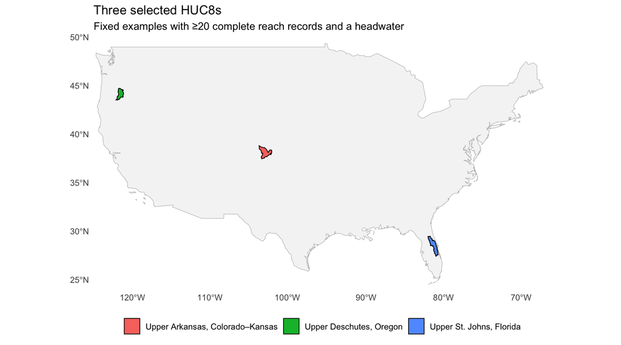

```r
conus <- ne_countries(
  country = "united states of america",
  scale = "medium",
  returnclass = "sf"
)

ggplot() +
  geom_sf(data = conus, fill = "grey96", color = "grey70", linewidth = 0.2) +
  geom_sf(
    data = selected_boundaries,
    aes(fill = region),
    color = "black",
    linewidth = 0.35
  ) +
  coord_sf(xlim = c(-125, -66), ylim = c(24, 50), expand = FALSE) +
  labs(
    title = "Three selected HUC8s",
    subtitle = "Fixed examples with ≥20 complete reach records and a headwater",
    fill = NULL
  ) +
  theme(panel.grid = element_blank(), legend.position = "bottom")
```

## 2. Draft ER watershed maps

These maps show the cached watershed boundary and annual mean ER for every qualifying flowline.

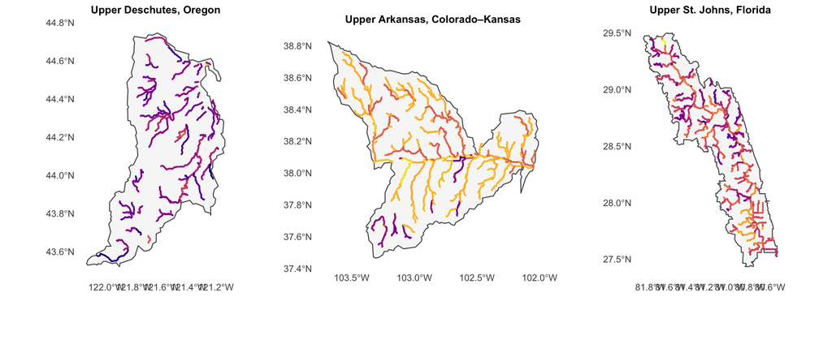

```r
er_map_row
```

## 3. Reach maps by process

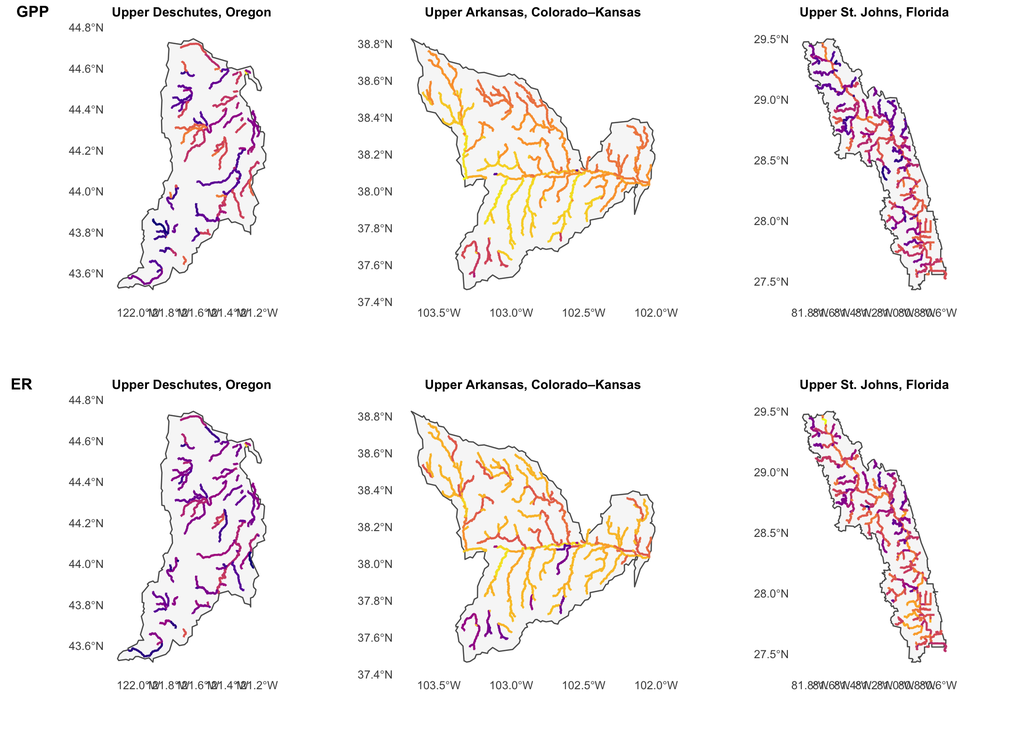

```r
plot_grid(
  gpp_map_row,
  er_map_row,
  ncol = 1,
  labels = c("GPP", "ER"),
  label_size = 12
)
```

## 4. Drainage-area relationships

The fitted lines are descriptive within-HUC8 summaries, not evidence of a causal drainage-area effect. Open points are headwater flowlines in the retained network.

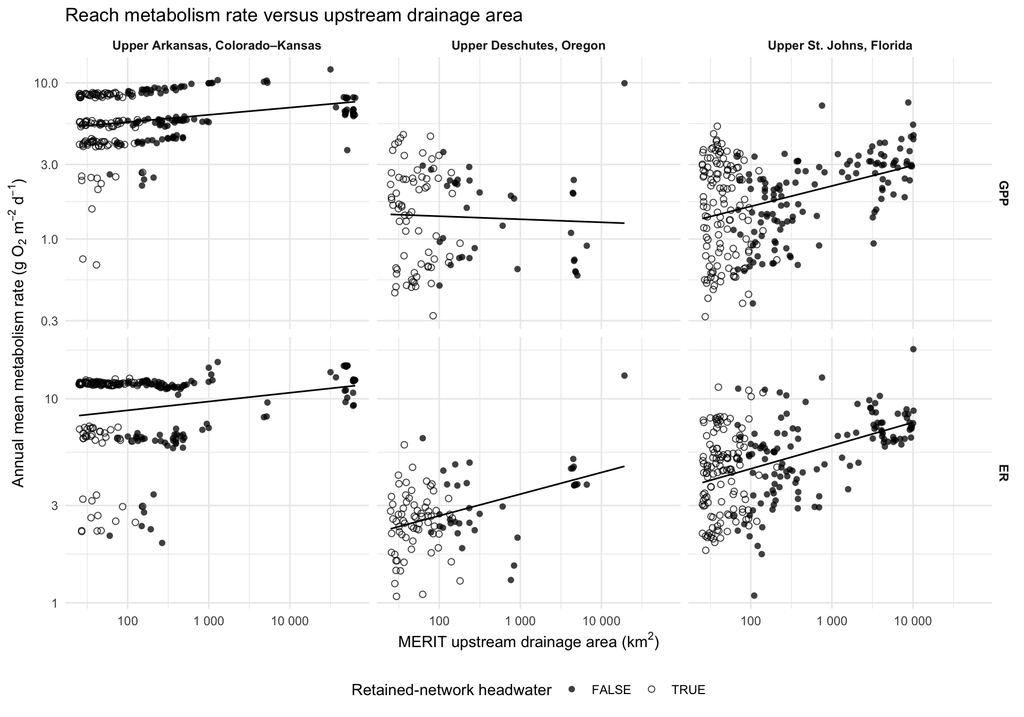

```r
ggplot(
  st_drop_geometry(selected_reaches),
  aes(uparea_km2, metabolism_g_o2_m2_d)
) +
  geom_point(
    aes(shape = is_headwater_retained),
    alpha = 0.75,
    size = 1.8
  ) +
  geom_smooth(method = "lm", se = FALSE, color = "black", linewidth = 0.55) +
  scale_x_log10(labels = label_number()) +
  scale_y_log10(labels = label_number()) +
  scale_shape_manual(
    values = c(`FALSE` = 16, `TRUE` = 21),
    name = "Retained-network headwater"
  ) +
  facet_grid(process ~ region, scales = "free_y") +
  labs(
    title = "Reach metabolism rate versus upstream drainage area",
    x = expression("MERIT upstream drainage area (km"^2*")"),
    y = expression("Annual mean metabolism rate (g "*O[2]*" m"^-2*" d"^-1*")")
  ) +
  theme(
    legend.position = "bottom",
    strip.text = element_text(face = "bold")
  )
```

## Interpretation prompt

Compare the shapes of the point clouds before interpreting the fitted lines: does metabolism vary systematically with drainage area within all three HUC8s, or do the relationships mainly differ by region or process? A repeated positive slope here would be more informative than the same pattern in a cumulative plot, because this version does not place the same upstream reaches into both axes.